# beatochess no. 05 (September 2024)

Beat Neuenschwander, email: neuenschwander.beat@gmail.com

This issue contains

# New studies

## EG 2022-2023 (1st prize)

File: Neuenschwander-2023-EG-1p.pgn

This study has a long history. It goes back to the year 1989, when I worked on a pawn ending with a reciprocal zugzwang position requiring the paradoxical move **1.a3!** (instead of **1.a4**) and allowing black to promote to a queen first.

About 8 years ago I took up the idea again but was unable to find the original version (which was, if I remember correctly, not particularly exciting despite the **festina lente** theme). So I had to start from scratch but was unable to find a decent realization, until last year. It was worth the wait as can be seen in the final version published in **EG**. The switch forth and back between queen and pawn endings adds a nice twist to the main theme of the study.

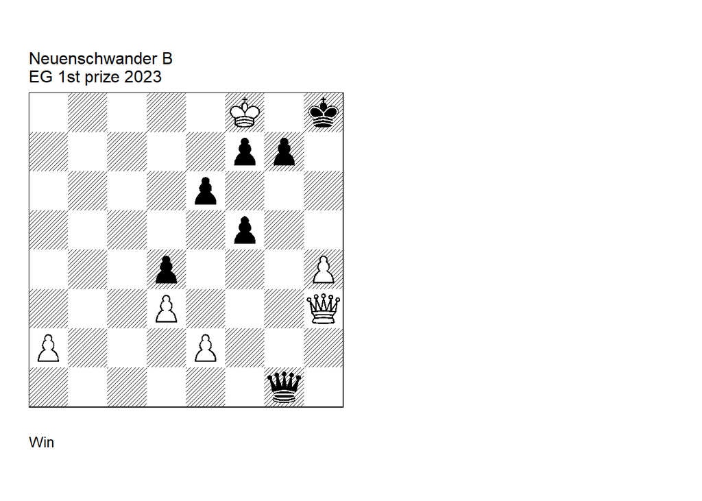

GBR: +4000.45f8h8 FEN: 5K1k/5pp1/4p3/5p2/3p3P/3P3Q/P3P3/6q1 w - - 0 1

**1. Qf3** (1. Kxf7? Kh7 2. Kxe6 Qg6+ 3. Kd5 Qf7+ 4. Kxd4 Qa7+ 5. Kc3 Qa3+ 6. Kd2 Qxa2+ 7. Ke3 Qe6+ 8. Kf2 Qe5 9. Qg3 Qd4+ 10. Kg2 g6 with only a minimal advantage for White ) (1. h5? Qg5 = ) **1… Qg6** (1… Qg4 2. a4 +/-) **2. Qf4** (2. a4? e5 3. Qd5 Qf6) **2… Qf6** (2… f6 3. Qxd4 Qg4 4. Qd7 Qb4+ 5. Kf7 Qb8 (5… Kh7 6. Qc8) 6. a4 and White wins easily ) **3. Qg5** (3. Qd6? f4 4. a4 Qf5 5. Qxd4 e5 gives White only a minimal edge, for example, 6. Qc4 f3 7. exf3 Qxf3 8. Qe4 (8. a5 Qb7 9. Qa4 Qa6 10. Kxf7 Qf6+ 11. Ke8 Qe6+ 12. Kd8 Qd6+ 13. Qd7 (13. Kc8 Qxd3 14. a6 Qd5 15. a7 Qc5+ 16. Kb7 Qe7+ 17. Kb6 Qd8+ 18. Kc5 Qf8+ 19. Kc4 Qf7+ = perpetual check ) 13… Qc5 14. Qa4 Qd6+ 15. Qd7 Qc5 16. Qc7 Qf8+ 17. Kd7 Qf5+ 18. Kc6 Qxd3 19. Qxe5) ) **3… Qxg5** (3… e5 4. Qxf6 gxf6 5. a4) **4. hxg5 e5 5. a3!!** ( After 5. a4? e4 6. a5 exd3 7. exd3 f4 8. a6 f3 9. a7 f2 10. a8=Q f1=Q , a position of mutual zugzwang arises, which Black holds with accurate play 11. Qb8 Qf2! 12. Qb7 Qh2! 13. Qc8 Kh7! 14. Qf5+ Kh8 15. Kxf7 Qc7+ = ) **5… e4 6. a4 exd3** (6… f4 7. a5 f3 8. exf3 e3 ( 8… exf3 leads to the main line ) 9. a6 e2 10. a7 e1=Q 11. a8=Q Qe6 (11… Kh7 12. Kxf7) 12. Qe4 Qd6+ 13. Kxf7 Qd7+ 14. Kf8 Qd6+ 15. Ke8 Qb8+ 16. Kf7 +/-) **7. exd3 f4 8. a5 f3 9. a6 f2 10. a7 f1=Q 11. a8=Q Now Black is in Zugzwang 11… Qf5** (11… Kh7 12. Qe4+ f5 13. gxf6+ Kh6 14. f7! +/-) **12. Qh1+ Qh7 13. Qxh7+ Kxh7 14. Kxf7 Kh8 15. Ke6 Kh7 16. Kf5!** (final Zugzwang) (16. Ke5? Kg6 17. Kxd4 Kxg5 18. Ke5 Kg6 19. Ke6 (19. d4 Kf7) 19… Kh7! 20. d4 g5 = ) **1-0**.

## Hornecker MT 2024 (2nd honorable mention)

File: Neuenschwander-2024-HorneckerMT.pgn

> Theme: A white piece occupies a square X at least twice during the solution, then leaves it. These occupations must be done without capture and without check. The thematic piece may not be the white king.

The thematic square is a1. The solution of the study is easy although some precision is needed towards the end.

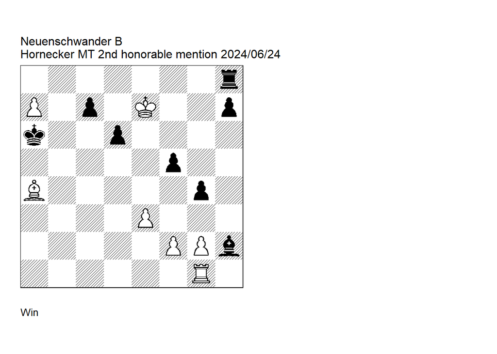

GBR: +0440.45e7a6 FEN: 7r/P1p1K2p/k2p4/5p2/B5p1/4P3/5PPb/6R1 w - - 0 1

**1. Ra1!** (theme) (1. Be8? Kxa7 2. Ra1+ Kb6 3. g3 h5 4. Rh1 h4 5. Rxh2 hxg3 6. Rg2 (6. Rxh8? g2) 6… Rh2 7. Rxg3 Rxf2 =) **1… Kxa7** (1… Be5 2. Be8+!) **2. g3** (2. Bd7+? Kb7 3. g3 h5 4. Rh1 h4 5. Rxh2 hxg3) **2… h5 3. Rh1 h4 4. Rxh2 hxg3 5. Rxh8 g2 6. Ra8+ Kb7** (6… Kb6 7. Rb8+) **7. Bc6+ Kxc6 8. Ra1!** (theme) **8… Kd5 9. Rg1 Ke4 10. Rxg2 d5 11. Kf6 c5** (11… Kf3 12. Rh2 c5 13. Kxf5) **12. Rg1! Back to the square where the rook started the round trip** (via the four corner squares) (12. Kg5? Kf3 13. Rh2 d4! 14. exd4 cxd4 15. Kxf5 d3 16. Ke5 d2 17. Rh1 Kxf2 =) (12. Rg3? c4 13. Kg5 c3 14. Rg1 g3! 15. Rxg3 (15. fxg3 Kxe3 16. Kxf5 c2 17. Rc1 Kd2 18. Rh1 Ke3! 19. Rc1 Kd2 20. Ra1 Ke3!) 15… c2 16. Rg1 f4! 17. exf4 d4) **1-0**.

## The Problemist (published)

Published in: The Problemist 29(11) September2024.

File: Neuenschwander-2024-TheProblemist-Sep.pgn

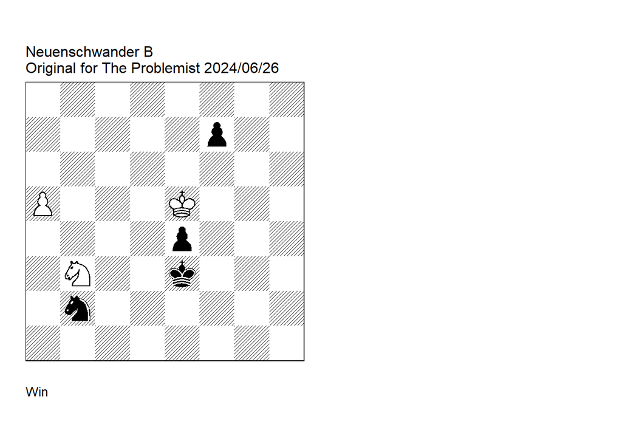

GBR: +0004.12e5e3 FEN: 8/5p2/8/P3K3/4p3/1N2k3/1n6/8 w - - 0 1

**1. Kd5** (1. a6? Nc4+) **1… Na4** (1… Nd3 2. Kc4 Nf4 (2… Ne5+ 3. Kb5 Nd7 4. a6) 3. Nd4! Ng6 4. Nf5+! (4. a6? Ne5+! (4… Ne7? 5. Nf5+) 5. Kb5 Kxd4 6. a7 e3 7. a8=Q e2 =) 4… Kf4 5. a6 Ne5+ 6. Kb5 Kxf5 7. a7 e3 8. a8=Q e2 9. Qh1 +-) (1… f5 2. a6 f4 3. a7 Na4 4. Kc6 =main line ) **2. Kc6 f5 3. a6 f4 4. a7 Nb6! 5. Kxb6 f3 6. Na5!!** (6. a8=Q? f2 7. Qf8 (7. Qa6 or ) 7… f1=Q 8. Qxf1) (6. Nd2? Kxd2 7. a8=Q f2 8. Qd5+ Ke2 9. Qxe4+ Kf1 =) (6. a8=R? f2 7. Ra1 (7. Rf8 Ke2 8. Nd4+ Ke1) 7… Kf4! 8. Kc5 e3 9. Nd4 Kg3 10. Kc4 Kg2) **6… f2 7. Nc4+ Kd3** (7… Ke2 8. a8=Q f1=Q 9. Qa2+ (9. Qxe4+? Kf2 =) 9… Kd3 10. Qb3+ Kd4 11. Nb2 leads to the main variation ) **8. a8=Q f1=Q 9. Qa3+** (9. Qd5+? Ke2 10. Qxe4+ Kf2 =) **9… Kd4** (9… Kxc4 10. Qa6+) (9… Kc2 10. Ne3+) (9… Ke2 10. Qe3+) **10. Qb2+** (10. Qc5+ Kd3 11. Qa3+ waste of time ) **10… Kd3** (10… Kd5 11. Ne3+) **11. Ne5+ Ke3 12. Ng4+ Kf4** (12… Kf3 13. Nh2+) (12… Kd3 13. Kb5) **13. Qf6+ 1-0**.

## Probleemblad (published)

Published in: Probleemblad nr. 03 2024.

File: Neuenschwander-2024-Probleemblad.pgn

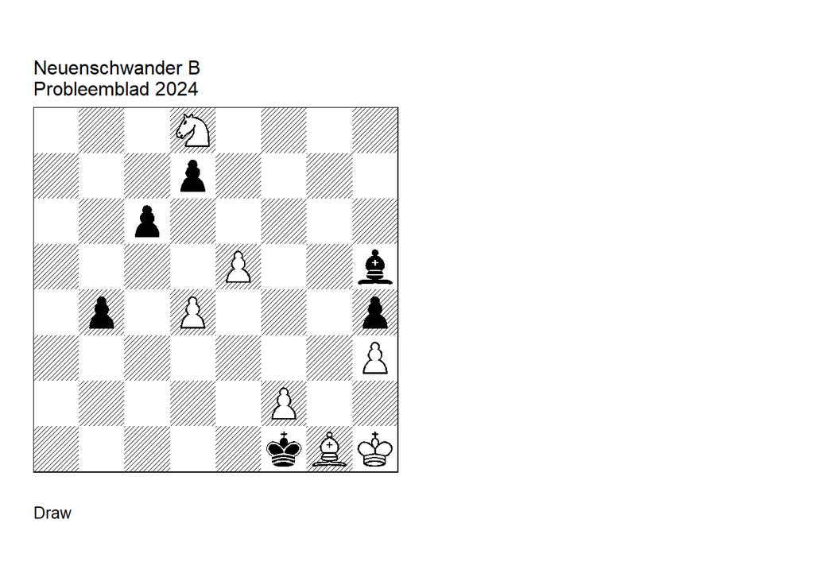

GBR: =0041.44h1f1 FEN: 3N4/3p4/2p5/4P2b/1p1P3p/7P/5P2/5kBK w - - 0 1

**1. Nb7 Bf3+ 2. Kh2 b3** (2… Ke2 3. Nc5 Kd2 (3… Kd1 4. Nxd7 b3 5. Nc5 b2 6. Na4) 4. Nxd7 b3 5. Nb6 =) **3. Na5 b2 4. Nc4 b1=N 5. d5! cxd5 6. e6! dxe6 7. Nd2+ Ke2 8. Nxb1 d4 9. Nd2!** (9. Nc3+? Ke1! -/+) (9. Na3? d3 10. Nc4 e5 -/+) **9… e5 10. Nb3!** (10. Nc4? d3 -/+) **10… Bd5 Tempo!** (10… Bc6 11. f4 =) **11. Nc5!** (11. Nc1+? Kd2 12. f4 Kxc1 13. fxe5 d3 14. Be3+ d2 15. Kg1 Kc2 -/+) **11… e4 12. Nd7!** (12. f3? e3! -/+) **12… d3 13. Nf6! Tempo! 13… Bc6 14. Ng4 d2 15. Ne3 This successfully ends the tour of the busy knight. 1/2-1/2**.

## Springaren (published)

Published in: Springaren nr. 170 June 2024.

File: Neuenschwander-2024-Springaren.pgn

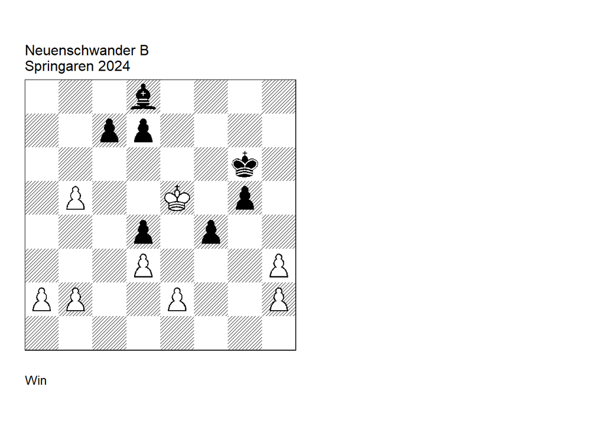

GBR: +0030.75e5g6 FEN: 3b4/2pp4/6k1/1P2K1p1/3p1p2/3P3P/PP2P2P/8 w - - 0 1

**1. a4 Be7 2. a5 Bb4** (2… Bc5 3. b6! cxb6 4. a6 b5 5. b4 Ba7 6. Kd6 Kf5 7. Kc7 Ke5 8. Kb7 Kd6 9. h4! (9. Kxa7? Kc7 10. Ka8 Kc8 =) 9… g4 10. h5 f3 11. exf3 gxf3 12. h6 f2 13. h7 f1=Q 14. h8=Q +/- Qxd3 15. Kxa7 +/-) **3. b6 f3!** (3… Bd6+ 4. Kd5 cxb6 5. Kxd6 bxa5 6. Kxd7 +/-) **4. exf3 Bxa5 5. b7 Bd2! 6. Ke4!** (6. b8=N? d6+ 7. Kxd4 Kf5 8. Na6 c6 9. Kc4 Kf4 10. b4 Be3 11. Nb8 d5+ 12. Kc3 c5 13. b5 Bd4+ 14. Kd2 c4 =) (6. b8=Q? Bf4+ 7. Ke4 d5+ 8. Kxd4 c5+ 9. Kxd5 Bxb8 =) **6… Bf4 7. b8=N! d6** (7… d5+ 8. Kxd5 c6+ 9. Nxc6) **8. Nc6** (8. b4? c5! =) **1-0**.

## Magyar Sakkvilag (published)

File: Neuenschwander-2024-MagyarSakkvilag.pgn

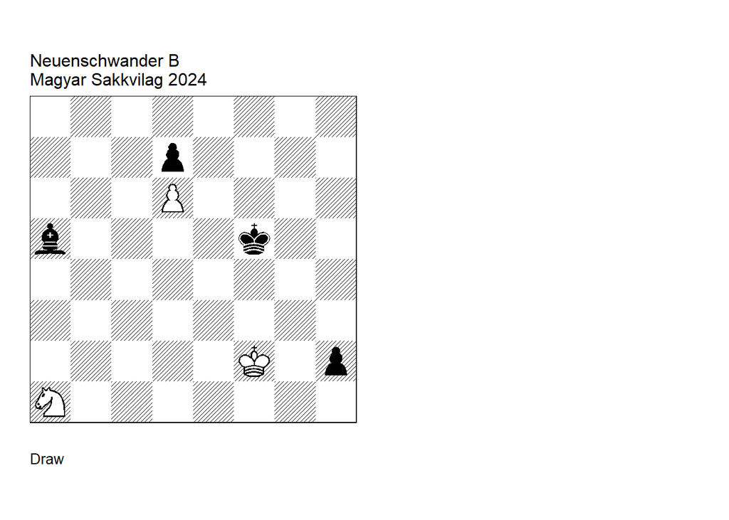

GBR: =0031.12f2f5 FEN: 8/3p4/3P4/b4k2/8/8/5K1p/N7 w - - 0 1

**1. Kg2 Bb6! Prepares the defence of the h-pawn.** (1… Ke4 2. Nb3! Bb4 ( 2… Bb6 3. Nd2+ = (3. Kxh2? Kd3) ) 3. Kxh2 =) (1… Ke4) **2. Nb3!** ( After 2. Kxh2? , the white knight cannot be saved. 2… Ke4 3. Nc2 Ba5 4. Na3 Kd3 5. Kg2 Bb4 6. Nb5 Kc4 7. Nc7 (7. Na7 Bxd6 8. Nc8 Bc5 -+) 7… Bxd6 8. Ne8 Be5 -+) **2… Bg1 3. Nc1!** (3. Na5? Ke5 4. Nb7 Kd5 -+) **3… Ke5 4. Na2! Ke6! Sets up a trap. 5. Kh1!** (5. Nb4? is premature because of 5… Bc5! -+) **5… Kxd6 6. Nb4! Ke6** (6… Kc5 7. Na6+! Kc4 8. Nb8! ( 8. Nc7 Bd4 -+) 8… d5 9. Nd7 d4 10. Ne5+ =) **7. Na6!** (7. Kg2? Bc5 -+) **7… Bd4!** (7… Kd5 8. Nb8 d6 9. Nd7 =) **8. Kg2!** (8. Kxh2? Be5+! 9. Kg2 Bd6! -+) **8… Kd5 9. Nb8! d6 10. Kxh2 Finally. 10… Ba7 11. Na6!** (11. Nd7? Ke6 12. Nf8+ Kf7 =) **1/2-1/2**.

# Comments and revisions

## Studies by Heuäcker

### Studies in HHdbVI

Heuäcker in HHdbVI

| no | res.gbr.Kk | comments | year | source |
| --- | --- | --- | --- | --- |
| 1 | +1001.01e6a1 |  | 1926 | Wiener Neueste Nachrichten |
| 2 | =0041.11a4d5 |  | 1927 | Kagan’s Neueste Schachnachrichten |
| 3 | +1000.16e6e3 |  | 1927 | Wiener Neueste Nachrichten |
| 4 | +0401.21h6h8 |  | 1927 | Wiener Schachzeitung#1115 |
| 5 | =0002.01f8a8 | U1 | 1928 | Wiener Neueste Nachrichten |
| 6 | +0117.00a6e8 | U1 | 1930 | source unknown |
| 7 | +0117.00a6f8 | (m) | 1930 | source unknown |
| 8 | +0634.04f1a6 |  | 1930 | Deutsch osterreichische Tageszeitung |
| 9 | +0040.11b1d8 | (m) | 1930 | Neue Freie Presse#44 |
| 10 | +0040.11c1h4 |  | 1930 | Neue Freie Presse#44 |
| 11 | +0131.12b7c4 |  | 1931 | Reichspost |
| 12 | =0433.00a1e8 | U1 | 1932 | Turmer |
| 13 | +0310.10g2g4 | U1 U2 | 1932 | Wiener Neueste Nachrichten |
| 14 | =0430.02a2a4 |  | 1932 | Reichspost |
| 15 | +0014.00c1a1 | U1 | 1935 | Deutsche Schachblatter#12 |
| 16 | +0311.23h3c5 | U1 | 1935 | Deutsche Schachzeitung#1920 |
| 17 | +0350.45h3c5 | (c) | 1935 | Deutsche Schachzeitung#1920 |
| 18 | =4003.00f1h1 |  | 1935 | Deutsche Schachzeitung#1924 |
| 19 | +0008.10h7f8 | (v) | 1937 | Deutsche Schachblatter |
| 20 | +0003.10g7e3 |  | 1937 | Deutsche Schachblatter#07 |
| 21 | +0000.22d7b4 | U3 | 1937 | Schach Beobachter Bayreuth |
| 22 | +0000.23d7b4 | (c) | 1937 | Schach Beobachter Bayreuth |
| 23 | +0008.10h7f8 |  | 1937 | Deutsche Schachblatter |
| 24 | +0104.02d8a5 |  | 1937 | Deutsche Schachblatter#02 |
| 25 | +0340.21a5h1 |  | 1937 | Deutsche Schachblatter#03 |
| 26 | =0301.11a4b1 |  | 1938 | Berliner Lokal-Anzeiger |
| 27 | +0316.21c1a7 |  | 1938 | Neue Illustrierte Zeitung |
| 28 | +0311.11c1a4 |  | 1938 | Deutsche Schachblatter#01 |
| 29 | +0340.13b1h1 |  | 1938 | Deutsche Schachblatter#06 |
| 30 | +4007.14e5g6 |  | 1938 | Schlesische Tageszeitung#391 |

[output cut: 103 more lines]

Date: 2024, August 17

File: Heuacker1938.pgn

**Study no. 31** (Table 1)

The cook can easily be avoided by placing the black rook on f5. Note that the minor dual on move 2 could also be avoided with the black rook on f7 in the starting position. However, this would remove some content.

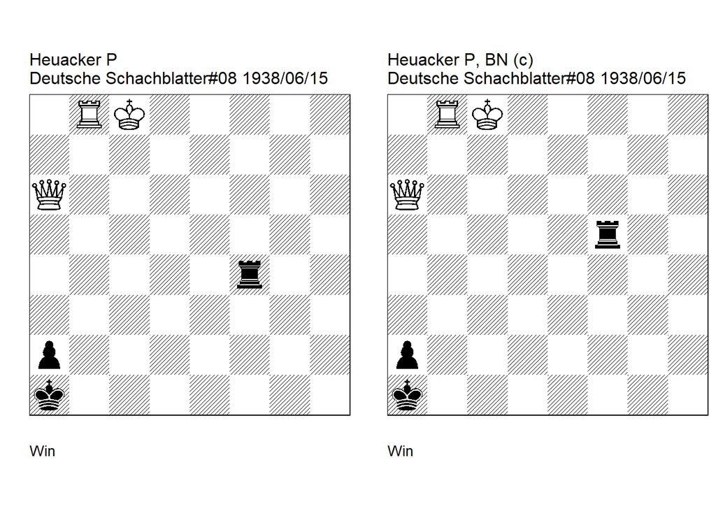

GBR: +1400.01c8a1 FEN: 1RK5/8/Q7/8/5r2/8/p7/k7 w - - 0 1

**Deutsche Schachblatter=12 . U1: Garcia=M EG=174 10/2008. 1. Qh6!** (1. Qe2? Rf8+ 2. Kc7 Rxb8 3. Qe5+ Kb1) (1. Ra8? Rf8+ 2. Kb7 Rxa8) (1. Rb6! cook MG 1… Rf8+ 2. Kd7 Rf7+ 3. Kc6 Rf6+ 4. Kb5 Rf5+ 5. Ka4 Ra5+ 6. Kb3 Rxa6 7. Rxa6) (1. Qc6? Rc4! 2. Qxc4) **1… Rf8+** (1… Rc4+ main 2. Kb7 Rb4+ 3. Kc6 Rc4+ 4. Kb5 Rc5+ 5. Kb6) **2. Kc7** (2. Kb7? Rxb8+) (2. Kd7 or ) **2… Rxb8** (2… Rf7+ 3. Kb6) **3. Qc1+ Rb1 4. Qc3+ Rb2 5. Qd4 Kb1 6. Qd1 1-0**.

GBR: +1400.01c8a1 FEN: 1RK5/8/Q7/5r2/8/8/p7/k7 w - - 0 1

**correction: Neuenschwander=B beatochess 17/08/2024. 1. Qh6!** (1. Qe2? Rf8+ 2. Kc7 Rxb8 3. Qe5+ Kb1) (1. Ra8? Rf8+ 2. Kb7 Rxa8) (1. Rb6? Rc5+ 2. Kd7 Rd5+ 3. Ke6 Re5+ 4. Kd6 Rd5+ 5. Kc6 Rc5+ 6. Kb7 Rc7+ 7. Ka8 Rc8+) (1. Qc6? Rc5) **1… Rf8+** (1… Rc5+ 2. Kb7 Rb5+ 3. Kc6 Rc5+ 4. Kb6) **2. Kc7** (2. Kb7? Rxb8+) (2. Kd7 or ) **2… Rxb8** (2… Rf7+ 3. Kb6) **3. Qc1+ Rb1 4. Qc3+ Rb2 5. Qd4 Kb1 6. Qd1 1-0**.

### Heuäcker =0002.01f8a8 (1928). Correction

Date: 2024, August 19

File: Heuacker1928.pgn

**Study no. 5** (Table 1)

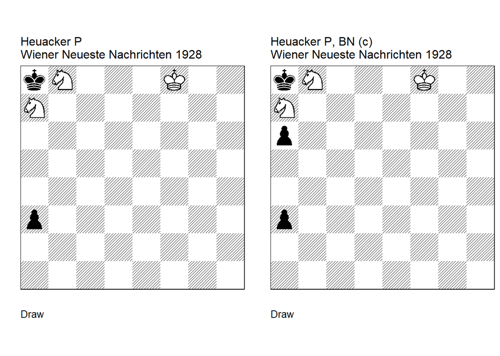

GBR: =0002.01f8a8 FEN: kN3K2/N7/8/8/8/p7/8/8 w - - 0 1

**U1: Conrady=H Internet 15-6-2003. 1. Nac6!** (1. Nbc6? a2 2. Na5 Kxa7 3. Nb3 Kb6) (1. Ke7! cook HC 1… a2 (1… Kxb8 2. Nc6+) (1… Kxa7 2. Nc6+ Kb6 3. Nb4) 2. Nac6 a1=Q 3. Nd7) **1… a2** (1… Kb7 2. Nb4) **2. Na5 a1=Q** ( 2… Kxb8 3. Nb3 Kc7 4. Ke7 Kc6 5. Ke6 Kb5 6. Kd5 Kb4 7. Na1 Kc3 8. Ke4 Kb2 9. Kd3 Kxa1 10. Kc2) **3. Nbc6! Qf6+** (3… Qe1 4. Kf7!) **4. Ke8!** (4. Kg8? Qf4 5. Kg7 Qf5 6. Kg8 Qf6 7. Kh7 Qg5 8. Kh8 Qg6) **4… Qd6 5. Kf7 Qh6 1/2-1/2**.

GBR: =0002.02f8a8 FEN: kN3K2/N7/p7/8/8/p7/8/8 w - - 0 1

**correction: Neuenschwander=B beatochess 19/08/2024. 1. Nac6!** (1. Nbc6? a2 2. Na5 Kxa7 3. Nb3 Kb6) **1… a2** (1… Kb7 2. Nb4) **2. Na5 a1=Q** (2… Kxb8 3. Nb3 Kc7 4. Ke7 Kc6 5. Ke6 Kb5 6. Kd5 Kb4 7. Na1 Kc3 8. Ke4 Kb2 9. Kd3 Kxa1 10. Kc2) **3. Nbc6! Qf6+** (3… Qe1 4. Kf7!) **4. Ke8!** (4. Kg8? Qf4 5. Kg7 Qf5 6. Kg8 Qf6 7. Kh7 Qg5 8. Kh8 Qg6) **4… Qd6 5. Kf7 Qh6 1/2-1/2**.

### Heuäcker +0311.23h3c5 (1935). Correction

Date: 2024, August 21

File: Heuacker1935.pgn

**Study no. 16** (Table 1)

The correction by the late Sarah-Siegfried Hornecker is quite heavy but has the advantage of showing a pure stalemate in the try. The new correction is closer to the original but the stalemate is not pure.

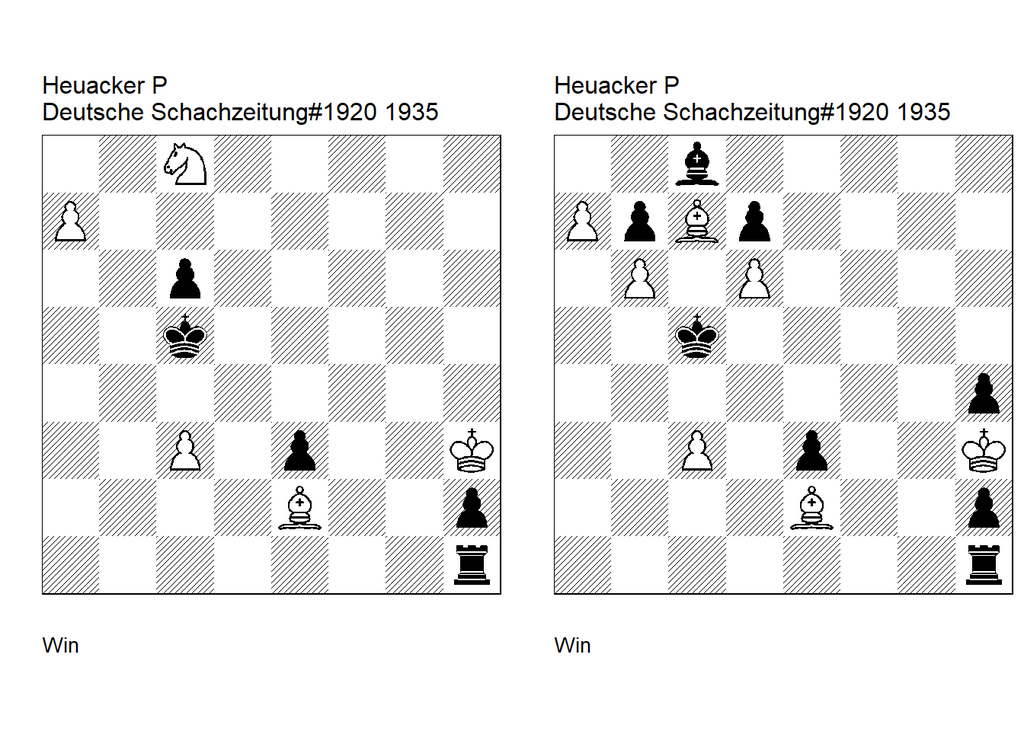

GBR: +0311.23h3c5 FEN: 2N5/P7/2p5/2k5/8/2P1p2K/4B2p/7r w - - 0 1

**Deutsche Schachzeitung/10. U1: Garcia=M HHdbV 68133 24-9-2011. 1. a8=R!** (1. a8=Q? Ra1 2. Qxa1 h1=Q+ 3. Qxh1) (1. Kg3! cook MG Ra1 2. Kxh2 Ra2 3. Kg3 Ra4 4. Kf3 Ra3 5. Kf4) (1. Bd3! cook MG Ra1 2. Kxh2) **1… Ra1 2. Rxa1 h1=Q+ 3. Rxh1 1-0**.

GBR: +0350.45h3c5 FEN: 2b5/PpBp4/1P1P4/2k5/7p/2P1p2K/4B2p/7r w - - 0 1

**Deutsche Schachzeitung/10. correction: Hornecker=S Die Schwalbe=298-1 8/2019. 1. a8=R!** (1. a8=Q? Ra1 2. Qxa1 h1=Q+ 3. Qxh1) **1… Ra1 2. Rxa1 h1=Q+ 3. Rxh1 1-0**.

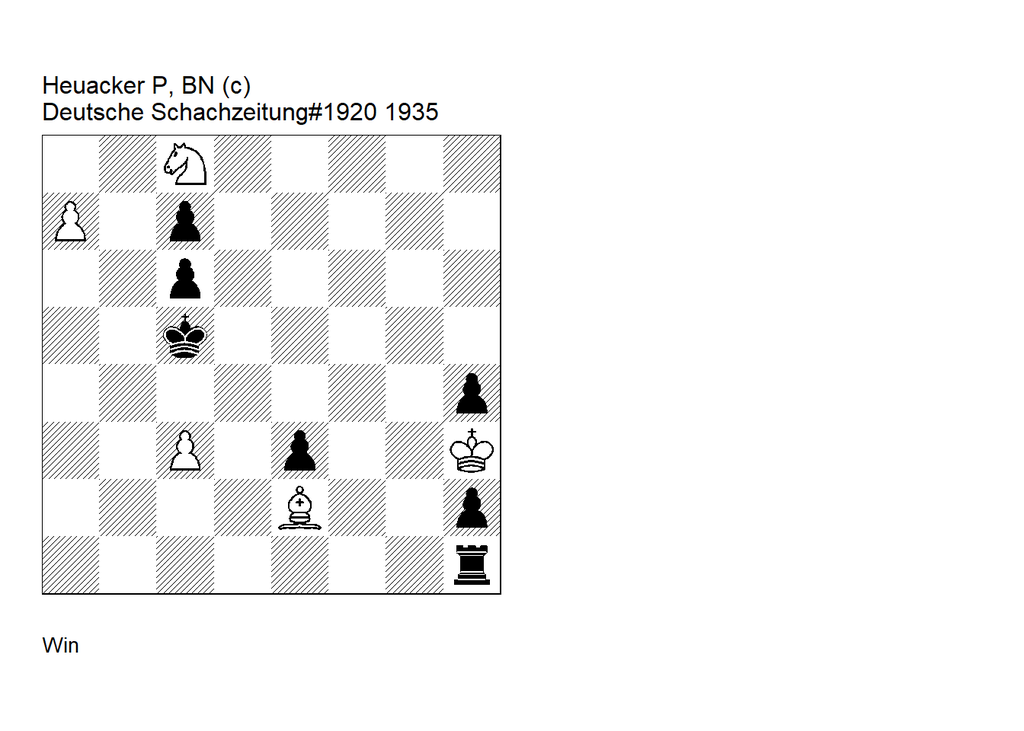

GBR: +0311.25h3c5 FEN: 2N5/P1p5/2p5/2k5/7p/2P1p2K/4B2p/7r w - - 0 1

**correction: Neuenschwander=B beatochess 21/08/2024. 1. a8=R!** (1. a8=Q? Ra1 2. Qxa1 h1=Q+ 3. Qxh1) **1… Ra1 2. Rxa1 h1=Q+ 3. Rxh1 1-0**.

### Heuäcker +0311.12g2b1 (1939). Correction

Date: 2024, August 22

File: Heuacker1939.pgn

**Study no. 36** (Table 1)

Mario Garcia’s correction is not very pleasing, in particular because of the knight on a1, which is captured in the first move. A same-material correction is possible.

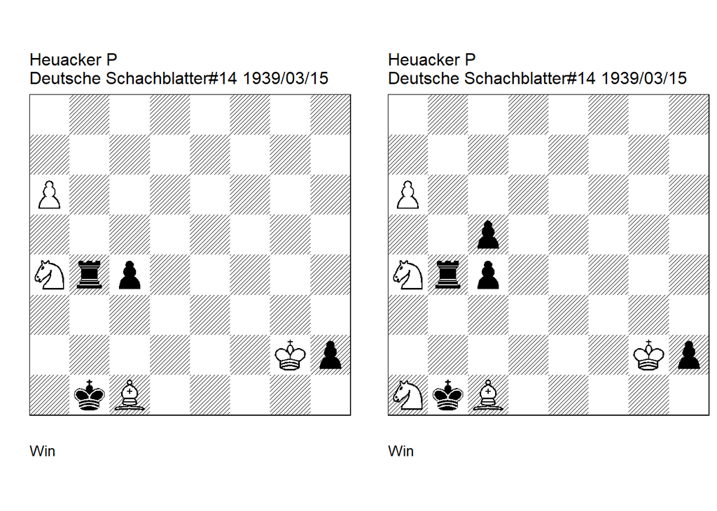

GBR: +0311.12g2b1 FEN: 8/8/P7/8/Nrp5/8/6Kp/1kB5 w - - 0 1

**Deutsche Schachblatter=6 . U2: Garcia=M Estudios Artisticos de Ajedrez - IV-41 2012. 1. Nc3+ Ka1!** (1… Kxc1 2. Na2+ Kd2 3. Nxb4) **2. a7 Rb8! 3. Bb2+** (3. axb8=Q? h1=Q+ 4. Kxh1) (3. Bf4! cook MG Ra8 4. Bb8 Kb2 5. Na4+ Kc2 6. Nb6 Rxa7 7. Bxa7 c3 8. Nd5) **3… Rxb2+ 4. Kh1 Rb8! 5. axb8=B!** (5. axb8=Q?) **1-0**.

GBR: +0312.13g2b1 FEN: 8/8/P7/2p5/Nrp5/8/6Kp/NkB5 w - - 0 1

**Deutsche Schachblatter=6 . correction: Garcia=M Estudios Artisticos de Ajedrez - IV-41 2012. 1. Nc3+! Kxa1!** (1… Kxc1 2. Na2+ Kd2 3. Nxb4) **2. a7 Rb8! 3. Bb2+** (3. Bf4? Ra8 4. Bb8 Kb2 5. Na4+ Kc1) ( 3. axb8=Q? h1=Q+ 4. Kxh1) **3… Rxb2+ 4. Kh1 Rb8! 5. axb8=B!** (5. axb8=Q? ) **1-0**.

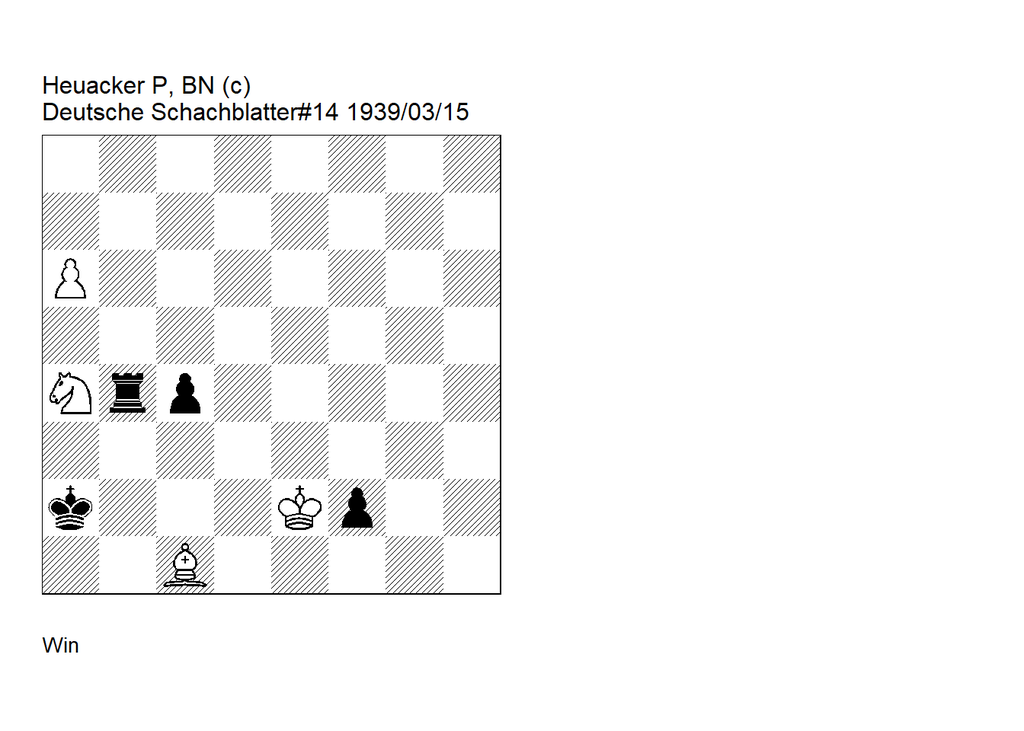

GBR: +0311.12g2b1 FEN: 8/8/P7/8/Nrp5/8/k3Kp2/2B5 w - - 0 1

**correction: Neuenschwander=B beatochess 22/08/2024. 1. Nc3+ Ka1 2. a7 Rb8 3. Bb2+!** (3. Bf4? Ra8 4. Bb8 Kb2 5. Na4+ Kb3 6. Nb6 Rxa7 7. Bxa7 c3) **3… Rxb2+ 4. Kf1 Rb8 5. axb8=B! 1-0**.

### Heuäcker =3500.11f1f3 (1949). Correction

Date: 2024, August 23

File: Heuacker1949.pgn

**Study no. 45** (Table 1)

The prize winner shows a remarkable mutual zugzwang position. The content of the correction is even richer.

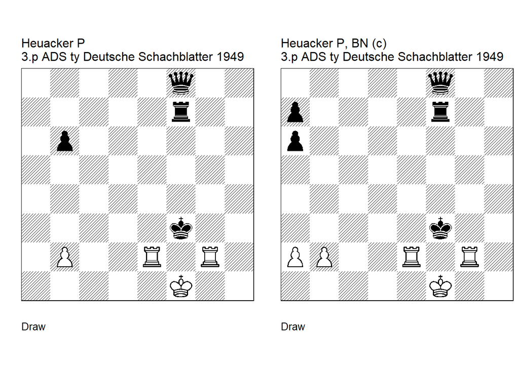

GBR: =3500.11f1f3 FEN: 5q2/5r2/1p6/8/8/5k2/1P2R1R1/5K2 w - - 0 1

**U3: Nunn=J HHdbIII 44698 31-8-2002. 1. b3!** (1. b4? b5) (1. Kg1? Rf4! 2. Rgf2+ Kg3 3. Re3+ (3. Rxf4 Qxf4 4. Rg2+ Kh3!) 3… Kh4 4. Re4 Qg7+) **1… b5** (1… Rf6 2. Rgf2+ Kg3 3. Re3+ Kg4 4. Re4+ Kg5 5. Re5+ Kg6 6. Re6) (1… Kf4 2. Kg1 Kf5 (2… Qc5+ 3. Ref2+ Ke4 4. Rg4+ Kd3 5. Rg3+ Kd4 6. Rxf7) 3. Rgf2+ Kg6 4. Rg2+ Kh7 5. Rh2+ Kg8 6. Rhg2+ Rg7 7. Rxg7+ Kxg7 8. Rg2+) (1… Qa8! cook JN 2. Ref2+ (2. Rgf2+ Kg3 3. Re3+ Rf3! (3… Qf3? 4. Rfxf3+ Rxf3+ 5. Ke2!) ) (2. Ra2 Qe4 3. Rgf2+ Kg3 4. Rxf7 Qb1+) 2… Ke3 3. Rg3+ Qf3 (3… Rf3 or ) ) **2. b4 Kf4 3. Kg1! Qxb4** (3… Rf6 4. Rgf2+ Kg3 5. Re3+ Rf3 6. Rg2+ Kh3 7. Rh2+) **4. Rgf2+ Kg3 5. Re3+ Kg4 6. Rxf7 Qd4 7. Rf3 b4 8. Kg2 1/2-1/2**.

GBR: =3500.22f1f3 FEN: 5q2/p4r2/p7/8/8/5k2/PP2R1R1/5K2 w - - 0 1

**correction: Neuenschwander=B beatochess 23/08/2024. 1. a3!!** (1. a4? a5! 2. b3 a6! 3. Kg1 Zugzwang 3… Rf4! 4. Ref2+ Ke4 5. Rg4 Rxg4+) (1. b3? a5! 2. a3 Kf4 3. Kg1 a4! 4. b4 a5! 5. bxa5 Qc5+ 6. Ref2+ Ke4 7. Rg4+ Kd3 8. Rg3+ Kc4 9. Rg4+ Kb5) (1. b4? a5! 2. bxa5 Kf4 3. Kg1 (3. a6 Kf5) 3… Qc5+) **1… a5** (1… Kf4 2. Kg1 Qc5+ 3. Ref2+ Ke4 4. Rg4+ Kd3 5. Rg3+ Kc4 (5… Kd4 6. Rxf7) 6. Rc3+) (1… Rf4 2. Ref2+ Ke3 3. Rg3+ Ke4 4. Rg4) (1… Qd6 2. Rgf2+ (2. Ref2+? Ke3 3. Rxf7 Qd1 ) 2… Kg3 3. Rxf7) (1… Qc5 2. Ref2+! ( 2. Rgf2+? Kg3 3. Rxf7 Qc1+ 4. Re1 Qc4+) 2… Ke3 3. Rg3+ Kd4 4. Rg4+) **2. a4!** (2. b3? Kf4 3. Kg1 a4!) **2… a6 3. b3! Mutual Zugzwang 3… Kf4 4. Kg1 Qc5+ 5. Ref2+ Ke4 6. Rg4+ Kd3 7. Rg3+ Ke4 8. Rg4+ 1/2-1/2**.

### Heuäcker +0134.01f1h8 (1952). Cook, version

Date: 2024, August 30

File: Heuacker1952.pgn

**Study no. 53** (Table 1)

A nice domination study; unfortunately, **4. Kf2!** wins as well. Moving the black pawn to d4 corrects the study and shows even richer content.

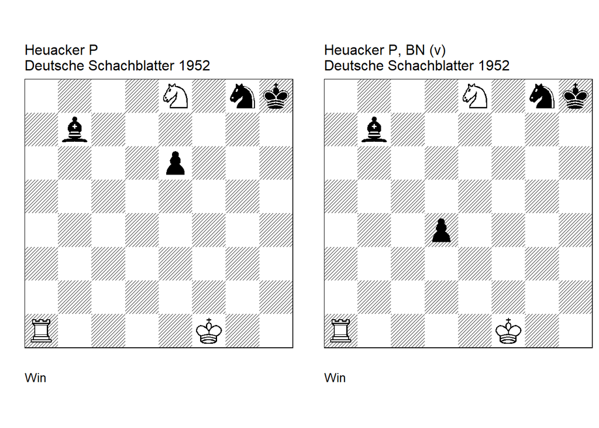

GBR: +0134.01f1h8 FEN: 4N1nk/1b6/4p3/8/8/8/8/R4K2 w - - 0 1

**U2: Neuenschwander=B beatochess 29/08/2024. 1. Ra3! Nh6** (1… Kh7 2. Ra7) **2. Rh3 Kh7 3. Nd6 Ba6+ 4. Ke1!** (4. Kg1? Kg6 5. Ra3 Be2) (4. Kf2! cook BN 4… Kg6 5. Ra3 Ng4+ 6. Kg3 Be2 7. Ra2 Bd1 8. Rd2) **4… Kg6 5. Ra3 1-0**.

GBR: +0134.01f1h8 FEN: 4N1nk/1b6/8/8/3p4/8/8/R4K2 w - - 0 1

**version: Neuenschwander=B 30/08/2024. 1. Ra2!** (1. Ra5? Nh6 2. Rh5 Kh7 3. Nd6 Ba6+ 4. Ke1 Kg6) **1… Nh6** (1… Ne7 2. Ra7) **2. Rh2 Ba6+** (2… Kh7 3. Nd6 Ba6+ leads to the main line ) **3. Ke1!** (3. Kf2? Kh7 4. Nd6 Kg6 5. Rg2+ Kf6 ) **3… Kh7 4. Nd6 Kg6 5. Rg2+! Kf6** (5… Kh5 main line 6. Rg3! (6. Kd2? Ng4!) 6… Ng4 (6… d3 7. Kd2 and the black bishop will be captured eventually ) (6… Ng4 7. Ra3) 7. Ra3) **6. Kd2!** (6. Rg3? Nf5! 7. Rf3 Bd3!) **6… Bf1** (6… Nf5 7. Rf2) **7. Rf2+ Ke6 8. Rxf1 Kxd6 9. Rf6+ 1-0**.

### Heuäcker +3141.01d1c4 (1954). Version

Date: 2024, September 1

File: Heuacker1954.pgn

**Study no. 60** (Table 1)

In addition to the cook **1… c2+!**, at the end of the study **6. Kc2** also wins. The version keeps the main theme of the study (domination of the queen), but the end of the study is different. Note the counter-checks: 2. Ne6+ fails to the counter-check 4… e2+!, and in the main line after the counter-check 5… Bb3+, precise play is required to ensure the win.

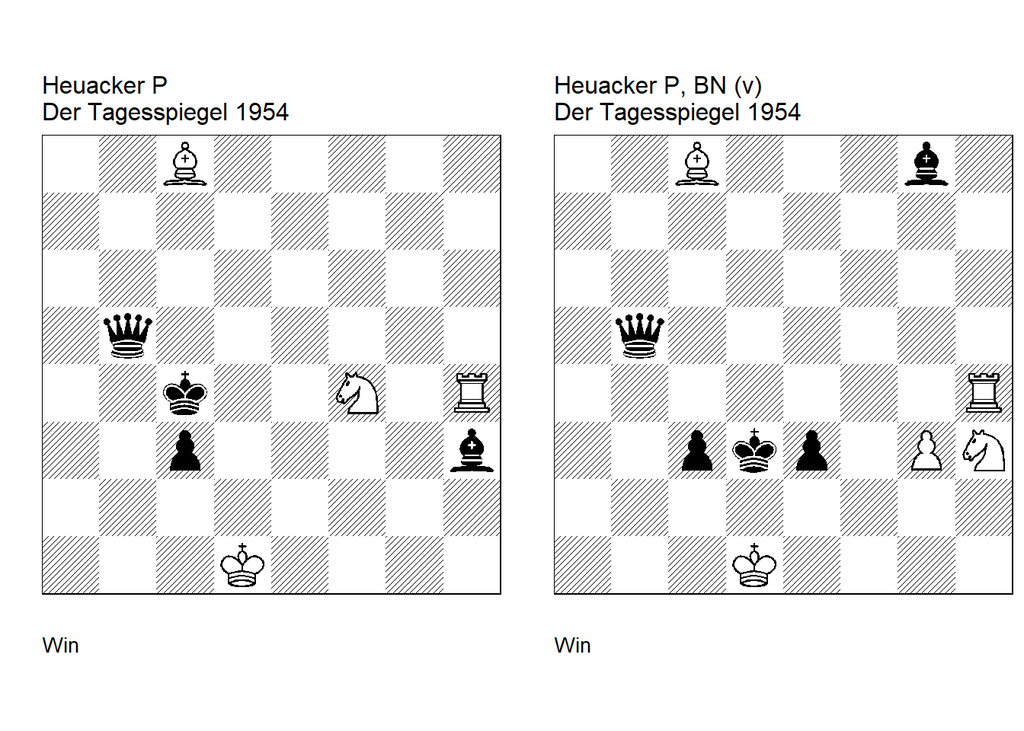

GBR: +3141.01d1c4 FEN: 2B5/8/8/1q6/2k2N1R/2p4b/8/3K4 w - - 0 1

**U3: Afek=Y HHdbVI 6-8-2020 U2: Neuenschwander=B beatochess 01/09/2024. 1. Ba6!** (1. Ne6+? Kb3! 2. Nd4+ Kb2 3. Nxb5 c2+ 4. Ke2 c1=Q 5. Rb4+ (5. Bxh3 Qc2+) 5… Ka1 6. Bxh3 Qc2+ 7. Ke3 Qc3+ 8. Nxc3) **1… Qxa6** (1… c2+! cook YA 2. Kd2 (2. Kxc2 Qxa6 3. Ne6+ Kb5 4. Nc7+ Kb6 5. Nxa6 Bf5+) 2… c1=Q+ 3. Kxc1 Qxa6 4. Ne6+ Kc3 5. Rxh3+ Qd3) **2. Ne6+ Kb3 3. Nc5+ Kb2 4. Rb4+ Ka3 5. Nxa6 Bf1** (5… Bc8 6. Rb6!) **6. Rb6!** (6. Kc2! cook BN 6… Bxa6 7. Kxc3) **1-0**.

GBR: +3141.01d1c4 FEN: 2B3b1/8/8/1q6/7R/2pkp1PN/8/3K4 w - - 0 1

**version: Neuenschwander=B beatochess 01/09/2024. 1. Nf4+ Kc4** (1… Ke4 2. Ne2+ (2. Ne6+ or ) 2… Kf3 3. Nd4+ Kf2 4. Rf4+ Kxg3 5. Rg4+) **2. Ba6!** (2. Ne6+? Kb3 3. Nd4+ Kb2 4. Rh2+ e2+! 5. Rxe2+ Qxe2+ 6. Nxe2 Bb3+ 7. Ke1 Bc4 8. Bf5 c2) **2… Qxa6** (2… c2+ 3. Kxc2 Qxa6 4. Ne6+) **3. Ne6+ Kb3 4. Nc5+ Kb2 5. Rb4+ Bb3+ 6. Rxb3+ Ka2 7. Nxa6 Kxb3 8. Nc5+** (8. Ke2? Kc4) **8… Kc4 9. Ne6** (9. Ne4? Kd4!) **9… Kd3 10. Nf4+ Kd4** (10… Ke4 11. Ke2 c2 12. Nd3 Kd4 13. Nc1) **1-0**.

### Heuäcker =3141.00d1f8 (1967). Correction

Date: 2024, September 9

File: Heuacker1967.pgn

**Study no. 125** (Table 1)

A short study with minimal content, which allows for a same-material correction.

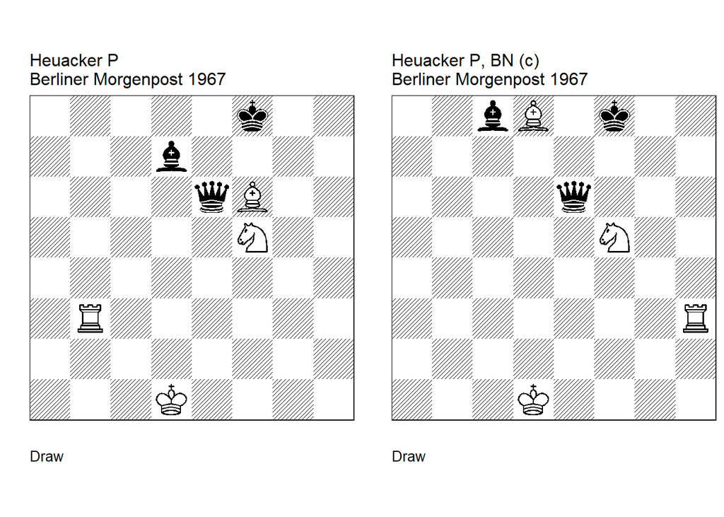

GBR: =3141.00d1f8 FEN: 5k2/3b4/4qB2/5N2/8/1R6/8/3K4 w - - 0 1

**U3: Konoval=Y Bourzutschky=M HHdbV 47003 28-7-2011. 1. Be7+** (1. Nd4? Qxf6 2. Rf3 Bg4) **1… Kf7** (1… Kg8 2. Rg3+ Kh7 (2… Kf7 3. Rg7+ Ke8 4. Nd6+) 3. Rh3+ Kg6 4. Rh6+) **2. Nd6+ Kxe7** (2… Kg6 3. Rg3+ Kh5 (3… Kh6! cook YK/MB ) (3… Kh7! cook YK/MB ) 4. Rg5+ (4. Rg7? Ba4+ 5. Kd2 Qd5+ 6. Kc1 Qd1+) 4… Kh6 (4… Kh4 5. Re5+) 5. Nf5+ Kh7 6. Rh5+ Kg8 7. Rg5+) **3. Re3 Qxe3 4. Nf5+ Bxf5 1/2-1/2**.

GBR: =3141.00d1f8 FEN: 2bB1k2/8/4q3/5N2/8/7R/8/3K4 w - - 0 1

**correction: Neuenschwander=B beatochess 09/09/2024. 1. Be7+** (1. Rh8+? Kf7 2. Rh7+ Kg8 3. Rg7+ Kh8) **1… Kf7 2. Nd6+ Kxe7** (2… Kg8 3. Rg3+ Kh7 4. Nxc8) **3. Re3 Qxe3 4. Nf5+ Bxf5 1/2-1/2**.

## Study be Stenicka

### Steniczka =0447.11h5h3 (1991). Cook, correction

Date: 2024, August 17

File: Steniczka1991.pgn

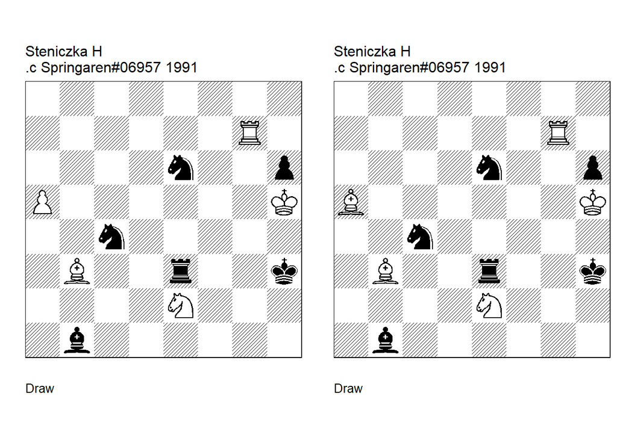

GBR: =0447.11h5h3 FEN: 8/6R1/4n2p/P6K/2n5/1B2r2k/4N3/1b6 w - - 0 1

**Springaren=46 Springaren/9** (EG 09362) **. U3: Garcia=M Estudios Artisticos de Ajedrez - X-43 2012. 1. Rg3+! Rxg3 2. Nxg3 Nf4+ 3. Kxh6 Nxa5** (3… Nd2! cook MG 4. Nh5 Nxh5 5. Bd5 Kh4 6. a6 Ne4 7. a7 Nef6 8. a8=Q Ng4 ) **4. Nh5! Nxh5 5. Be6+ Kh4 6. Bf5! Ba2 7. Bb1! Bb3 8. Bc2 Bc4 9. Bd3 Bd5 10. Be4 Bf7 11. Bg6 Bg8 12. Bh7 Ba2 13. Bb1 Bxb1 1/2-1/2**.

GBR: =0457.01h5h3 FEN: 8/6R1/4n2p/B6K/2n5/1B2r2k/4N3/1b6 w - - 0 1

**Springaren=46 Springaren/9. correction: Garcia=M Estudios Artisticos de Ajedrez - X-43 2012 U1: Neuenschwander=B beatochess 17/08/2024. 1. Rg3+!** (1. Ng1+ cook BN 1… Kh2 2. Bc7+ Nxc7 (2… Kh1 3. Rg3) 3. Bxc4) (1. Rb7 cook BN 1… Nxa5 2. Bxe6+) **1… Rxg3 2. Nxg3 Nf4+ 3. Kxh6 Nxa5 4. Nh5 Nxh5 5. Be6+ Kh4 6. Bf5 Ba2 7. Bb1 Bb3 8. Bc2 Bc4 9. Bd3 Bd5 10. Be4 Bg8 11. Bh7 Ba2 12. Bb1 Bxb1 1/2-1/2**.

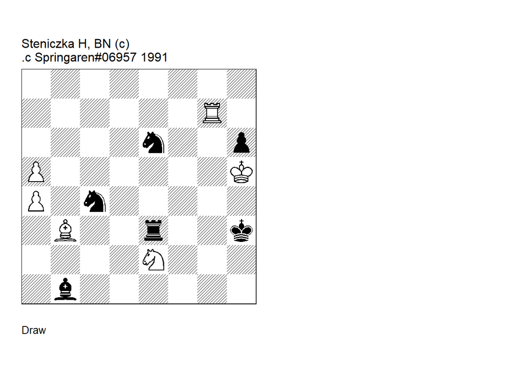

GBR: =0447.21h5h3 FEN: 8/6R1/4n2p/P6K/P1n5/1B2r2k/4N3/1b6 w - - 0 1

**correction: Neuenschwander=B beatochess 17/08/2024. 1. Rg3+! Rxg3 2. Nxg3 Nf4+ 3. Kxh6 Nxa5** (3… Nd2 4. Ne2! (4. Nh5? Nxh5 5. Bd5 Kh4 6. a6 Ne4 7. a7 Nef6 8. Be6 Be4) (4. a6? Kxg3) 4… Nxe2 5. Bd5 Nc3 6. Bb7) **4. Nh5! Nxh5 5. Be6+ Kh4 6. Bf5! Ba2 7. Bb1! Bb3 8. Bc2 Bc4 9. Bd3 Bd5 10. Be4 Bf7 11. Bg6 Bg8 12. Bh7 Ba2 13. Bb1 Bxb1 1/2-1/2**.